# 第五章 离散时间傅里叶变换

## 冲激列采样

频域 band-limited CT signal $X(j \omega)=0$ for $|\omega|>\omega_{M}$

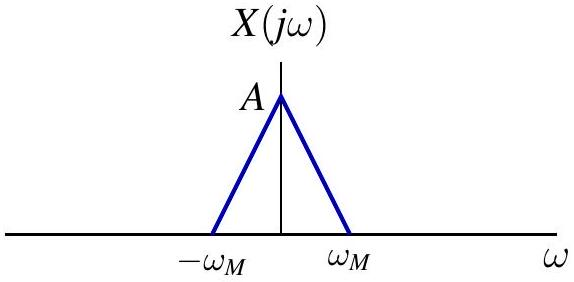

Sampling frequency $\omega_{s}=\frac{2 \pi}{T}$

Case 1: $\omega_{s}>2 \omega_{M}$ no overlap between replicas can recover $X$ by lowpass filtering

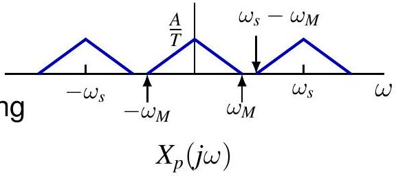

Case 2: $\omega_{s}<2 \omega_{M}$ replicas overlap cannot recover $X$

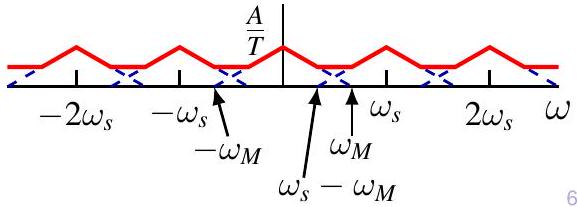

## 采样定理

Band-limited CT signal $x(t)$ whose spectrum $X(j \omega)=0$ for $|\omega|>\omega_{M}$ is uniquely determined by its samples $x(n T), n \in \mathbb{Z}$ if

$$\omega_{s} \triangleq \frac{2 \pi}{T}>2 \omega_{M}, \quad 2 \omega_{M} \text { called Nyquist rate }$$

Given $\{x(n T): n \in \mathbb{Z}\}, x(t)$ can be reconstructed as follows

1. construct $x_{p}(t)=\sum_{n=-\infty}^{\infty} x(n T) \delta(t-n T)$
2. send $x_{p}$ through lowpass filter with gain $T$ and cutoff frequency $\omega_{c} \in\left(\omega_{M}, \omega_{s}-\omega_{M}\right)$, i.e.

$$H(j \omega)=T\left[u\left(\omega+\omega_{c}\right)-u\left(\omega-\omega_{c}\right)\right]$$

3. filter output $x_{r}(t)$ with $X_{r}(j \omega)=X_{p}(j \omega) H(j \omega)$ is same as $x(t)$

## 频域中的重建

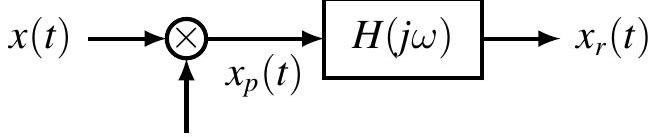

$$p(t)=\sum_{n=-\infty}^{\infty} \delta(t-n T)$$

- Nyquist frequency $\omega_{M}$
- Nyquist rate $2 \omega_{M}$

Lowpass filter

- gain $T$
- cutoff frequency

$$\omega_{M}<\omega_{c}<\omega_{s}-\omega_{M}$$

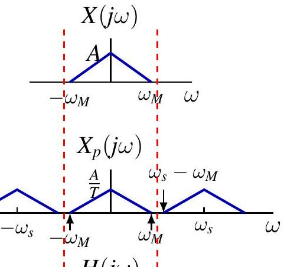

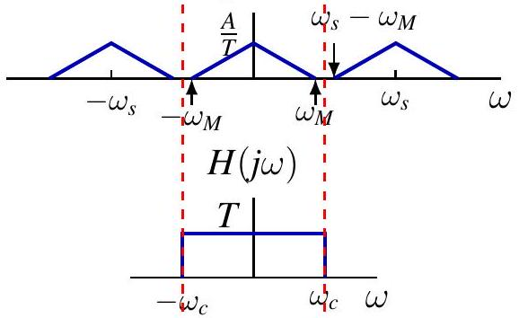

## 时域中的重建

Impulse response of lowpass filter

$$h(t)=\frac{T \sin \left(\omega_{c} t\right)}{\pi t}$$

$x$ recovered by band-limited interpolation using sinc function

$$x(t)=x_{r}(t)=\left(x_{p} * h\right)(t)=\sum_{n=-\infty}^{\infty} x(n T) \frac{T \sin \left(\omega_{c}(t-n T)\right)}{\pi(t-n T)}$$

## 时域中的重建

$$\omega_{c}=\frac{\omega_{s}}{2}=\frac{\pi}{T}$$

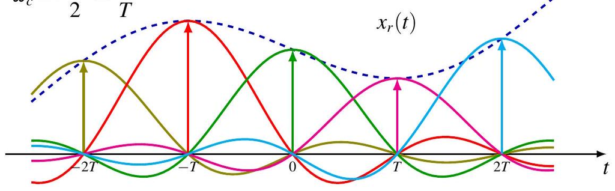

## 时域中的重建

Setting $\omega_{c}=\frac{\omega_{s}}{2}$ yields Whittaker-Shannon interpolation formula

$$x_{r}(t)=\sum_{n=-\infty}^{\infty} x(n T) \operatorname{sinc}\left(\frac{t-n T}{T}\right), \quad \text { where } \operatorname{sinc}(t)=\frac{\sin (\pi t)}{\pi t}$$

Since

$$\operatorname{sinc}\left(\frac{t-n T}{T}\right) \stackrel{\mathcal{F}}{\longleftrightarrow} T e^{-j n T \omega}\left[u\left(\omega+\frac{\pi}{T}\right)-u\left(\omega-\frac{\pi}{T}\right)\right]$$

Parseval’s identity (or multiplication property) implies

$$\int_{\mathbb{R}} \operatorname{sinc}\left(\frac{t-n T}{T}\right) \operatorname{sinc}\left(\frac{t-m T}{T}\right) d t=\frac{T^{2}}{2 \pi} \int_{-\frac{\pi}{T}}^{\frac{\pi}{T}} e^{j(m-n) T \omega} d \omega=T \delta[n-m]$$

Whittaker-Shannon formula is orthogonal expansion

## 时域中的重建

$$\omega_{c}=\frac{\omega_{s}}{4}=\frac{\pi}{2 T}>\omega_{M}$$

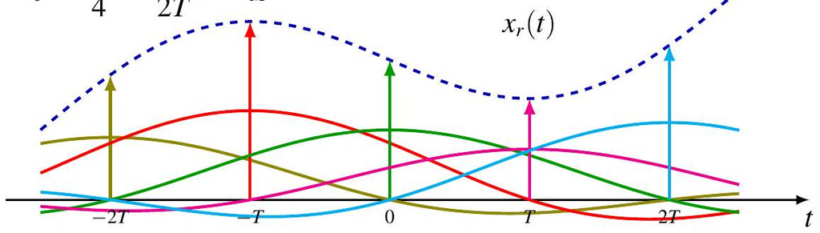

## 时域中的重建

$$\omega_{c}=\frac{3 \omega_{s}}{5}<\omega_{s}-\omega_{M}$$

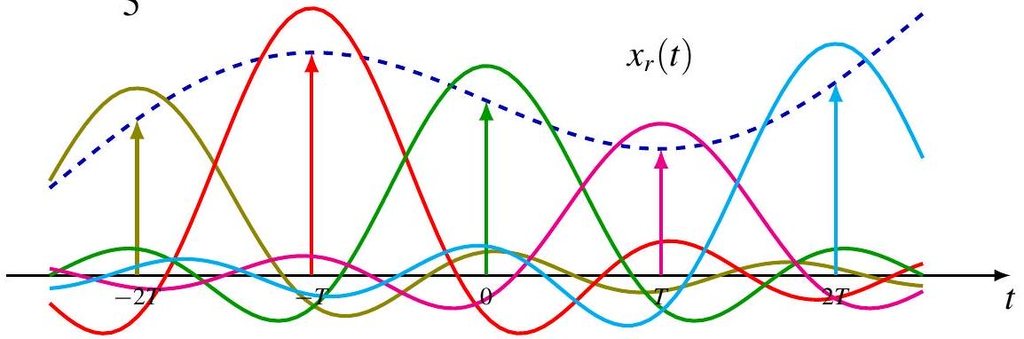

## 目录

## 1. 采样定理

2. 零阶保持与线性插值

## 3. 混叠

## 其他插值方法

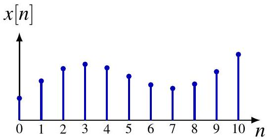

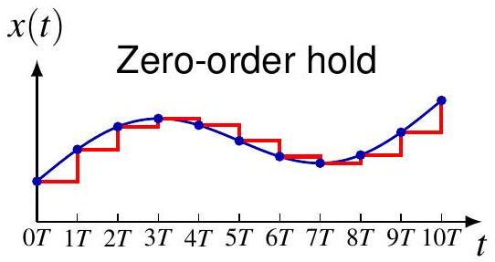

$T=$ sampling period

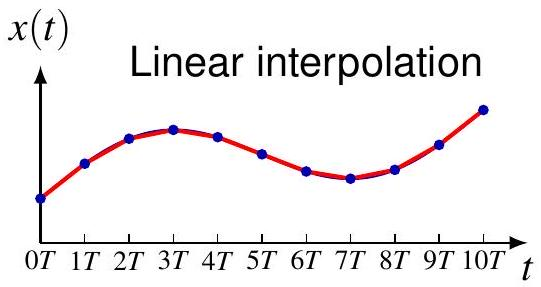

## 零阶保持

Reconstructed signal

$$x_{0}(t)=\left(x_{p} * h_{0}\right)(t)=\sum_{n=-\infty}^{\infty} x(n T) h_{0}(t-n T)$$

Zero-order hold filter

$$H_{0}(j \omega)=e^{-j \omega T / 2} \frac{2 \sin (\omega T / 2)}{\omega}$$

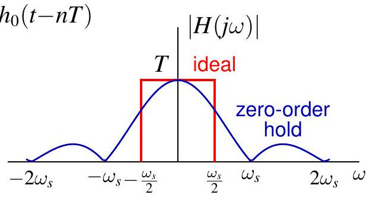

## 零阶保持

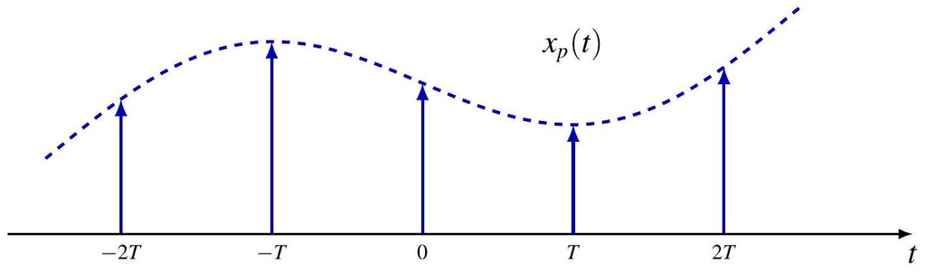

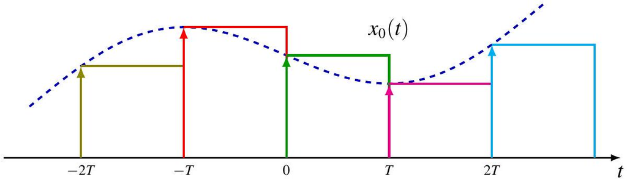

## 线性插值 (First-order Hold)

Reconstructed signal

$$x_{1}(t)=\left(x_{p} * h_{1}\right)(t)=\sum_{n=-\infty}^{\infty} x(n T) h_{1}(t-n T)$$

First-order hold filter

$$H_{1}(j \omega)=\frac{1}{T}\left[\frac{\sin (\omega T / 2)}{\omega / 2}\right]^{2}$$

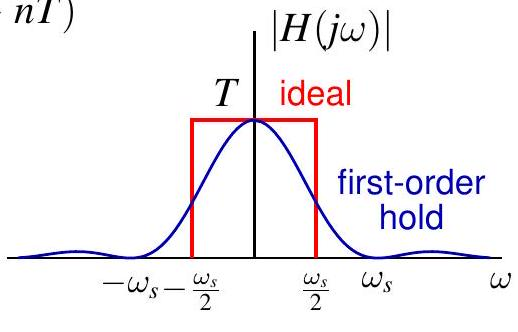

## 线性插值

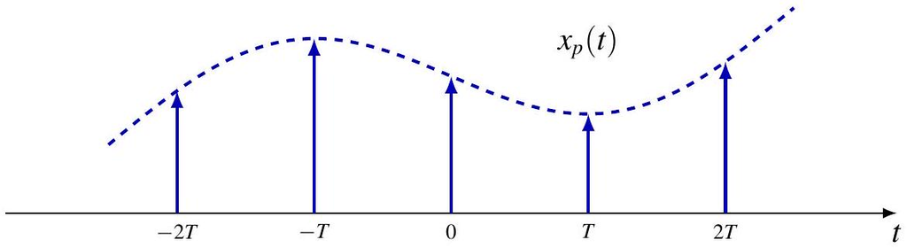

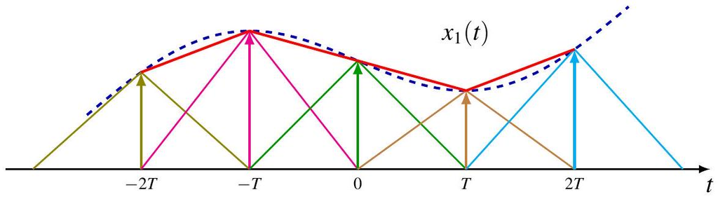

## 目录

## 1. 采样定理

2. 零阶保持与线性插值
3. 混叠

## 混叠

混叠 wraps frequencies

## output frequency

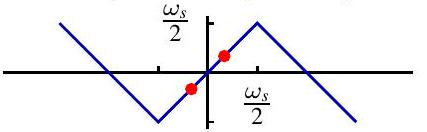

input frequency

$$\begin{aligned}
x(t) & =\cos \left(\omega_{0} t+\phi\right) \\
\omega_{0} & <\frac{1}{2} \omega_{s}
\end{aligned}$$

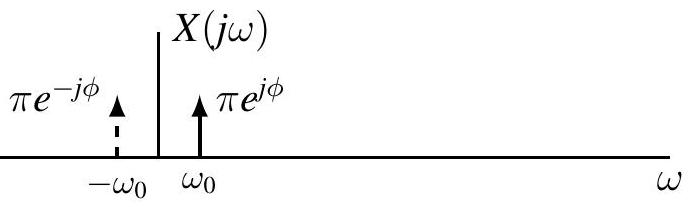

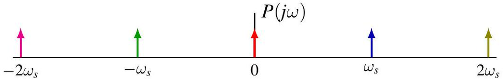

$$x_{r}(t)=\cos \left(\omega_{0} t+\phi\right)$$

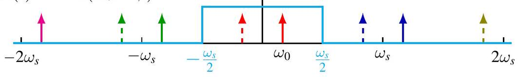

## 混叠

混叠 wraps frequencies